## To Go Further

During the previous studies, we conclude that it is the **Boosting methods** that seemed to be the most efficient, despite a computation time that can sometimes be important. The robustness of this family of algorithms pushes us to explore more, especially two new algorithms: the **XGBoost** and the **Stochastich Boosting Models**.

### XGBoost : Improvment of Gradient Boosting

**XGBoost** stands for e**X**treme **G**radient **B**oosting, which is one of the most popular and efficient implementations of the **Gradient Boosted Trees algorithm**. It has both **linear model solver and tree learning algorithms**. The algorithm loss function is based on second order Taylor approximation, which is a sum of simple quadratic functions of one variable. The algorithm works as NewtonRaphson in function space, unlike gradient boosting that works as gradient descent in function space. XGBoost algorithm works with 3 types of parameters :

- **general parameters** : refers to which booster we are using to do boosting (generally tree ot linear model).
- **booster parameters** : depends on which booster has been chose.
- **learning task parameters** : decides on the learning scenario.

The loss function to minimize in XGBoost algorithm is given by :

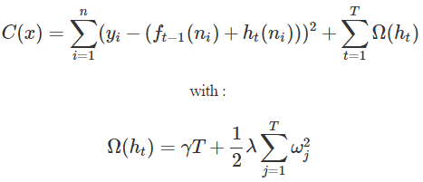

### The SAMME.R Algorithm : Improvment of Adaboost

The **SAMME algorithm**, or **S**tagewise **A**dditive **M**odeling algorithm, is very similar to Adaboost with **the only difference that the only constraint needed for the model weight in each iteration to be positive is that the accuracy of each weak classifier be better thant random guessing** (that is 0.5). It then puts more weight on the misclassified data points than Adaboost. A variant of this algorithm is the **SAMME.R algorithm**, which gives all the models an **equal weight of one**. In fact, while SAMME is a **discrete-valued algorithm**, meaning that it outputs either 0 or 1 in case of binary classification, **SAMMER.R uses class probabilities**, meaning that it outputs the **probability of a sample belonging to a class**. We talk about « **Real Boosting** », since it outputs a real-valued number.